# Predictive Policing in Chicago, IL

Chris Michael

October 20, 2022

# A. Introduction

### The Purpose of Predictive Policing

Predictive Policing is a step towards reducing policing bias, brutality and unwarranted surveillance within communities. This concept becomes increasing important particularly in a time where the country has been experiencing a surge in weapons related violence. This study aims to understand the relationships between *weapons violations* and spatial variables, to predict future crime hotspots in the city of *Chicago*. It is important to note however, that crime is heavily dependent on numerous other externalities that is beyond the scope of study at this time. This model can be a useful tool that could serve as a base model for future predictive policing for cities in the U.S.

# B. Set-Up

### I. Installing Packages

```r
library(tidyverse)
library(sf)
library(RSocrata)
library(viridis)
library(spatstat)
library(raster)
library(spdep)
library(FNN)
library(grid)
library(gridExtra)
library(RColorBrewer)
library(knitr)
library(kableExtra)
library(tidycensus)
library(classInt)
library(kableExtra)
library(RColorBrewer)
library(hrbrthemes)
library(ggthemes)
library(ggplot2)
library(plotly)
library(scales)
library(extrafont)
library(basetheme)
library(RColorBrewer)
library(lemon)
library(data.table)
library(GGally)
require(gridExtra)
library(ggalt)
library(rgeos)
library(sp)
library(smoothr)
library(rgdal)
library(rgeos)
library(maptools)
library(ggmap)
library(scales)
library(ggeasy)
library("wesanderson")
library(spdep)
library(caret)
library(ckanr)
library(FNN)
library(grid)
library(ggcorrplot)
library(corrr)
library(kableExtra)
library(jtools)
library(ggstance)
library(ggpubr)
library(broom.mixed)
library(tab)
library(sjPlot)
library(plotly)
library(stargazer)

col <- wes_palette("Zissou1")
col5 <- colorRampPalette(col)(5)
col6 <- colorRampPalette(col)(6)
col7 <- colorRampPalette(col)(7)
col8 <- colorRampPalette(col)(8)
col10 <- colorRampPalette(col)(10)
col22 <- colorRampPalette(col)(22)
col29 <- colorRampPalette(col)(29)
col96 <- colorRampPalette(col)(96)

options(scipen = 999)
options(tigris_class = "sf")

root.dir = "https://raw.githubusercontent.com/urbanSpatial/Public-Policy-Analytics-Landing/master/DATA/"
source("https://raw.githubusercontent.com/urbanSpatial/Public-Policy-Analytics-Landing/master/functions.r")
```

I started creating the markdown by installing the required packages and loading them into the library. Some of the mainly used packages are `tidyverse`, `tidycensus`, and `dplyr`. The final deliverable for this homework is an RMarkdown file with the required plots and tables, knitted to a HTML document.

# C. Chicago Crime Data

### I. Reading the Data

I used the `socrata` package for pulling data. The reason I chose weapons violations as the type of crime I wanted to take a closer look at is because of the increasing number of weapons related violent crime that has been occuring in the U.S. Coming from a country with stringent weapon control laws, it was interesting to study the relationship between weapons violations and spatial variables.

```r
policeDistricts <-
  st_read("https://data.cityofchicago.org/api/geospatial/fthy-xz3r?method=export&format=GeoJSON") %>%
  st_transform('ESRI:102271') %>%
  dplyr::select(District = dist_num)


policeBeats <-
  st_read("https://data.cityofchicago.org/api/geospatial/aerh-rz74?method=export&format=GeoJSON") %>%
  st_transform('ESRI:102271') %>%
  dplyr::select(District = beat_num)

bothPoliceUnits <- rbind(mutate(policeDistricts, Legend = "Police Districts"),
                         mutate(policeBeats, Legend = "Police Beats"))

weaponsvio <-
  read.socrata("https://data.cityofchicago.org/Public-Safety/Crimes-2017/d62x-nvdr") %>%
    filter(Primary.Type == "WEAPONS VIOLATION") %>%
    mutate(x = gsub("[()]", "", Location)) %>%
    separate(x,into= c("Y","X"), sep=",") %>%
    mutate(X = as.numeric(X),Y = as.numeric(Y)) %>%
    na.omit() %>%
    st_as_sf(coords = c("X", "Y"), crs = 4326, agr = "constant")%>%
    st_transform('ESRI:102271') %>%
    distinct()

chicagoBoundary <-
  st_read(file.path(root.dir,"/Chapter5/chicagoBoundary.geojson")) %>%
  st_transform('ESRI:102271')
```

### II. Visualizing the Point Data

The maps below show the reported cases of weapons violations in Chicago in 2017 as well as the spatial density of the crime. From the density map, we can see that there is a higher rate of incidences in the **west side** of Chicago (denoted in red), as well as when we move further **south**.

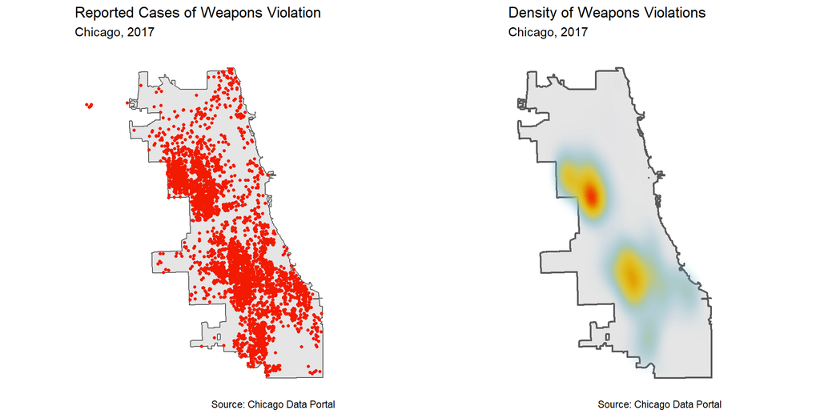

```r
A <- ggplot() +
  geom_sf(data = chicagoBoundary, size=0.5) +
  geom_sf(data = weaponsvio, colour="#f21a00", size=1, show.legend = "point") +
  labs(title="Reported Cases of Weapons Violation",
       subtitle="Chicago, 2017\n",
       caption="Source: Chicago Data Portal")+
  theme_void()

pal <- wes_palette("Zissou1", 20, type = "continuous")

B <- ggplot() +
  geom_sf(data = chicagoBoundary, size=0.75) +
  stat_density2d(data = data.frame(st_coordinates(weaponsvio)),
                 aes(X, Y, fill = ..level.., alpha = ..level..),
                 size = 0.01, bins = 40, geom = 'polygon',show.legend = FALSE) +
  scale_fill_gradientn(colors=pal) +
  scale_alpha(range = c(0.00, 0.35), guide = FALSE) +
  labs(title="Density of Weapons Violations",
       subtitle="Chicago, 2017\n",
       caption="Source: Chicago Data Portal")+
  theme_void()

ggarrange(A,B, align="v")
```

### III. Creating the Fishnet

The maps in this section shows the fishnet overlaid over Chicago as well as the count of weapons violations for each fishnet cell. The clustering of weapons violation related crime can be noticed in this map.

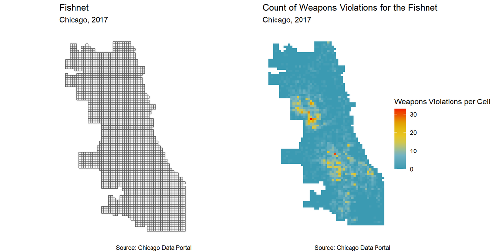

```r
fishnet <-
  st_make_grid(chicagoBoundary,
               cellsize = 500,
               square = TRUE) %>%
  .[chicagoBoundary] %>%
  st_sf() %>%
  mutate(uniqueID = 1:n())

C <- ggplot()+
  geom_sf(data = fishnet)+
  labs(title="Fishnet",
       subtitle="Chicago, 2017\n",
       caption="Source: Chicago Data Portal")+
  theme_void()

crime_net <-
  dplyr::select(weaponsvio) %>%
  mutate(countWeaponsVio = 1) %>%
  aggregate(., fishnet, sum) %>%
  mutate(countWeaponsVio = replace_na(countWeaponsVio, 0),
         uniqueID = 1:n(),
         cvID = sample(round(nrow(fishnet) / 24),
                       size=nrow(fishnet), replace = TRUE))

D <- ggplot() +
  geom_sf(data = crime_net, aes(fill = countWeaponsVio), color = NA) +
  scale_fill_gradientn(colors=col10, name="Weapons Violations per Cell") +
  labs(title = "Count of Weapons Violations for the Fishnet",
       subtitle="Chicago, 2017\n",
       caption="\nSource: Chicago Data Portal")+
  theme_void()

ggarrange(C,D, align="v")
```

# D. Investigating Risk Factors

### I. Pulling Risk Factor Data

In order to investigate the relationship of weapons violations to spatial features, I utilized data from the `Chicago Open Data Portal`. The spatial risk factors include police stations, fire stations, grocery stores, liquor retail stores, places without functional street lights and abandoned buildings. These variables were chosen based on the assumption that their proximity could potentially have an effect on weapons related crime.

```r
PoliceStations <-
  read.socrata("https://data.cityofchicago.org/resource/z8bn-74gv.json") %>%
  dplyr::select(Y = latitude, X = longitude) %>%
    na.omit() %>%
    st_as_sf(coords = c("X", "Y"), crs = 4326, agr = "constant") %>%
    st_transform(st_crs(fishnet)) %>%
    mutate(Legend = "Police Stations")

FireStations <-
  read.socrata("https://data.cityofchicago.org/resource/28km-gtjn.json") %>%
  dplyr::select(Y = location.latitude, X = location.longitude) %>%
    na.omit() %>%
    st_as_sf(coords = c("X", "Y"), crs = 4326, agr = "constant") %>%
    st_transform(st_crs(fishnet)) %>%
    mutate(Legend = "Fire Stations")

LiquorRetail <-
  read.socrata("https://data.cityofchicago.org/resource/nrmj-3kcf.json") %>%
    filter(business_activity == "Retail Sales of Packaged Liquor") %>%
    dplyr::select(Y = latitude, X = longitude) %>%
    na.omit() %>%
    st_as_sf(coords = c("X", "Y"), crs = 4326, agr = "constant") %>%
    st_transform(st_crs(fishnet)) %>%
    mutate(Legend = "Liquor Retail")

StreetLightsOut <-
  read.socrata("https://data.cityofchicago.org/Service-Requests/311-Service-Requests-Street-Lights-All-Out/zuxi-7xem") %>%
    mutate(year = substr(creation_date,1,4)) %>% filter(year == "2017") %>%
    dplyr::select(Y = latitude, X = longitude) %>%
    na.omit() %>%
    st_as_sf(coords = c("X", "Y"), crs = 4326, agr = "constant") %>%
    st_transform(st_crs(fishnet)) %>%
    mutate(Legend = "Street Lights Out")

AbandonBuildings <-
  read.socrata("https://data.cityofchicago.org/Service-Requests/311-Service-Requests-Vacant-and-Abandoned-Building/7nii-7srd") %>%
    mutate(year = substr(date_service_request_was_received,1,4)) %>%  filter(year == "2017") %>%
    dplyr::select(Y = latitude, X = longitude) %>%
    na.omit() %>%
    st_as_sf(coords = c("X", "Y"), crs = 4326, agr = "constant") %>%
    st_transform(st_crs(fishnet)) %>%
    mutate(Legend = "Abandoned Buildings")

GroceryStores <-
  read.socrata("https://data.cityofchicago.org/Community-Economic-Development/Map-of-Grocery-Stores-2013/ce29-twzt")%>%
    dplyr::select(Y = LATITUDE, X = LONGITUDE) %>%
    na.omit() %>%
    st_as_sf(coords = c("X", "Y"), crs = 4326, agr = "constant") %>%
    st_transform(st_crs(fishnet)) %>%
    mutate(Legend = "Grocery Stores")

neighborhoods <-
  st_read("https://raw.githubusercontent.com/blackmad/neighborhoods/master/chicago.geojson") %>%
  st_transform(st_crs(fishnet))
```

### II. Visualizing Risk Factor Data

The set of maps show the spatial risk factors as points. It is important to note the distribution and clustering of these points in relation to the crime data.

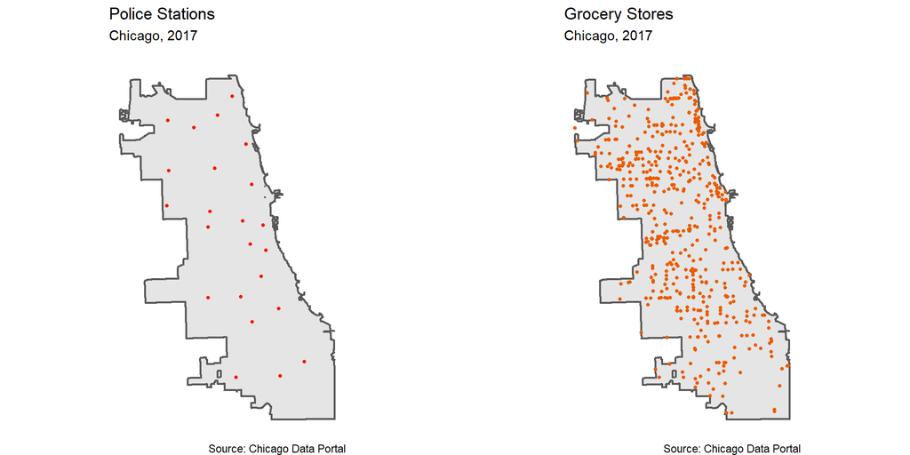

```r
E <- ggplot() +
  geom_sf(data = chicagoBoundary, size=0.75) +
  geom_sf(data = PoliceStations, colour="#f21a00", size=1, show.legend = "point") +
  labs(title="Police Stations",
       subtitle="Chicago, 2017\n",
       caption="Source: Chicago Data Portal")+
  theme_void()

G <- ggplot() +
  geom_sf(data = chicagoBoundary, size=0.75) +
  geom_sf(data = GroceryStores, colour="#ea5c00", size=1, show.legend = "point") +
  labs(title="Grocery Stores",
       subtitle="Chicago, 2017\n",
       caption="Source: Chicago Data Portal")+
  theme_void()

H <- ggplot() +
  geom_sf(data = chicagoBoundary, size=0.75) +
  geom_sf(data = FireStations, colour="#e67d00", size=1, show.legend = "point") +
  labs(title="Fire Stations",
       subtitle="Chicago, 2017\n",
       caption="Source: Chicago Data Portal")+
  theme_void()

I <- ggplot() +
  geom_sf(data = chicagoBoundary, size=0.75) +
  geom_sf(data = LiquorRetail, colour="#e4b80e", size=1, show.legend = "point") +
  labs(title="Liquor Retail Stores",
       subtitle="Chicago, 2017\n",
       caption="Source: Chicago Data Portal")+
  theme_void()

J <- ggplot() +
  geom_sf(data = chicagoBoundary, size=0.75) +
  geom_sf(data = StreetLightsOut, colour="#9ebe91", size=0.5, show.legend = "point") +
  labs(title="Street Lights Out",
       subtitle="Chicago, 2017\n",
       caption="Source: Chicago Data Portal")+
  theme_void()

K <- ggplot() +
  geom_sf(data = chicagoBoundary, size=0.75) +
  geom_sf(data = AbandonBuildings, colour="#63adbe", size=1, show.legend = "point") +
  labs(title="Abandoned Buildings",
       subtitle="Chicago, 2017\n",
       caption="Source: Chicago Data Portal")+
  theme_void()

ggarrange(E,G, align = "v")
```

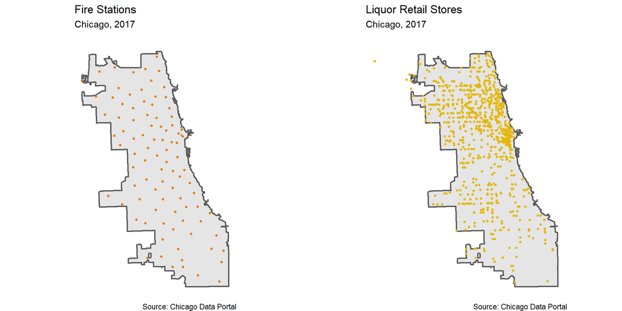

```r
ggarrange(H,I, align = "v")
```

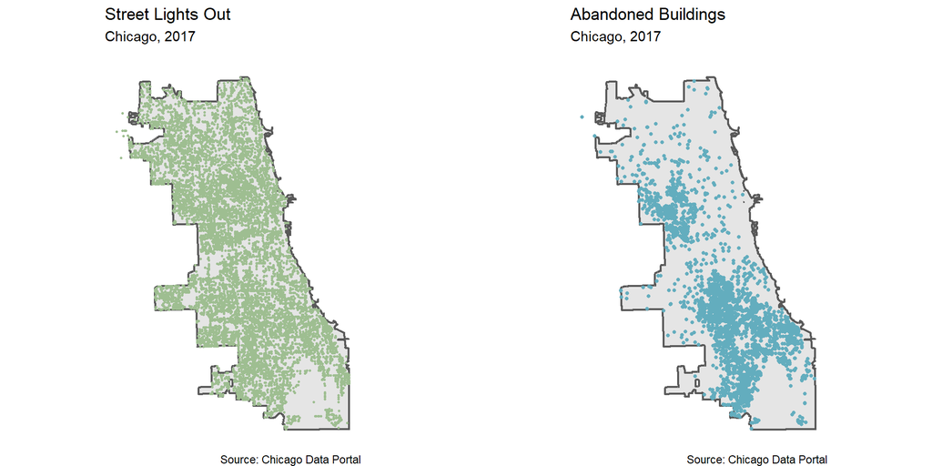

```r
ggarrange(J,K, align = "v")
```

# D. Feature Engineering

### I. Risk Factors by Fishnet

The maps below shows the clustering of the risk factors for each fishnet cell. This is later useful for aggregation by k nearest neighbor and other spatial functions. This row of maps shows the density of spatial features.

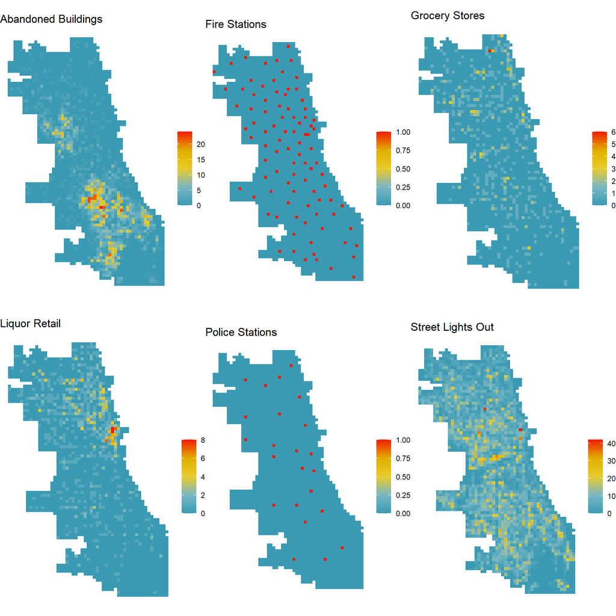

```r
st_c <- st_coordinates
st_coid <- st_centroid

vars_net <-
  rbind(PoliceStations, GroceryStores, FireStations, LiquorRetail,
        StreetLightsOut, AbandonBuildings) %>%
  st_join(., fishnet, join=st_within) %>%
  st_drop_geometry() %>%
  group_by(uniqueID, Legend) %>%
  summarize(count = n()) %>%
    full_join(fishnet) %>%
    spread(Legend, count, fill=0) %>%
    st_sf() %>%
    dplyr::select(-`<NA>`) %>%
    na.omit() %>%
    ungroup()

vars_net.long <-
  gather(vars_net, Variable, value, -geometry, -uniqueID)

vars <- unique(vars_net.long$Variable)
mapList <- list()

for(i in vars)
  mapList[[i]] <-
    ggplot() +
      geom_sf(data = filter(vars_net.long, Variable == i), aes(fill=value), colour=NA) +
      scale_fill_gradientn(colors=pal, name="") +
      labs(title=i) +
      theme_void()

do.call(ggarrange,c(mapList))
```

### II. K Nearest Neighbor

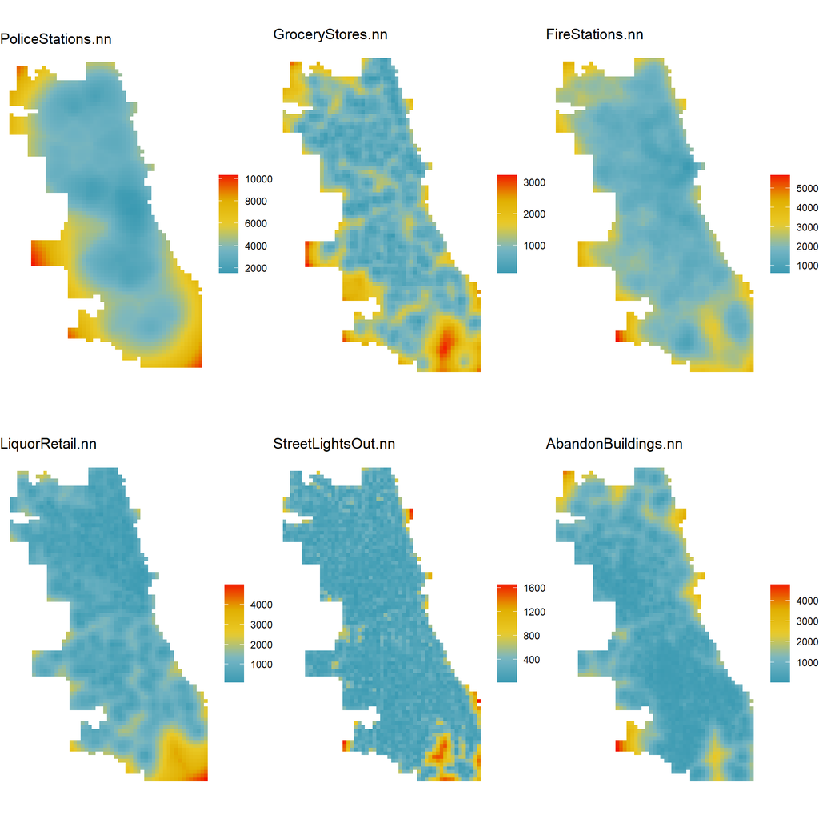

```r
vars_net <- vars_net %>%
    dplyr::mutate(PoliceStations.nn = nn_function(st_c(st_coid(vars_net)),
                                           st_c(PoliceStations),
                                           k = 3),
           GroceryStores.nn = nn_function(st_c(st_coid(vars_net)),
                                           st_c(GroceryStores),
                                           k = 3),
           FireStations.nn = nn_function(st_c(st_coid(vars_net)),
                                           st_c(FireStations),
                                           k = 3),
           LiquorRetail.nn = nn_function(st_c(st_coid(vars_net)),
                                           st_c(LiquorRetail),
                                           k = 3),
           StreetLightsOut.nn = nn_function(st_c(st_coid(vars_net)),
                                           st_c(StreetLightsOut),
                                           k = 3),
           AbandonBuildings.nn = nn_function(st_c(st_coid(vars_net)),
                                           st_c(AbandonBuildings),
                                           k = 3))
vars_net1 <- vars_net %>%
  select(-c(3:8))

vars_net.long.nn <-
  gather(vars_net1, Variable, value, -geometry, -uniqueID)

vars <- unique(vars_net.long.nn$Variable)
mapList <- list()

for(i in vars)
  mapList[[i]] <-
    ggplot() +
      geom_sf(data = filter(vars_net.long.nn, Variable == i), aes(fill=value), colour=NA) +
      scale_fill_gradientn(colors=pal, name="") +
      labs(title=i) +
      theme_void()

do.call(ggarrange,c(mapList))
```

### III. Joining

The various layers are finally joined into a `final_net` table that is ready for regressions. The maps in this section just show the police districts and neighborhoods, overlaid with the fishnet grid.

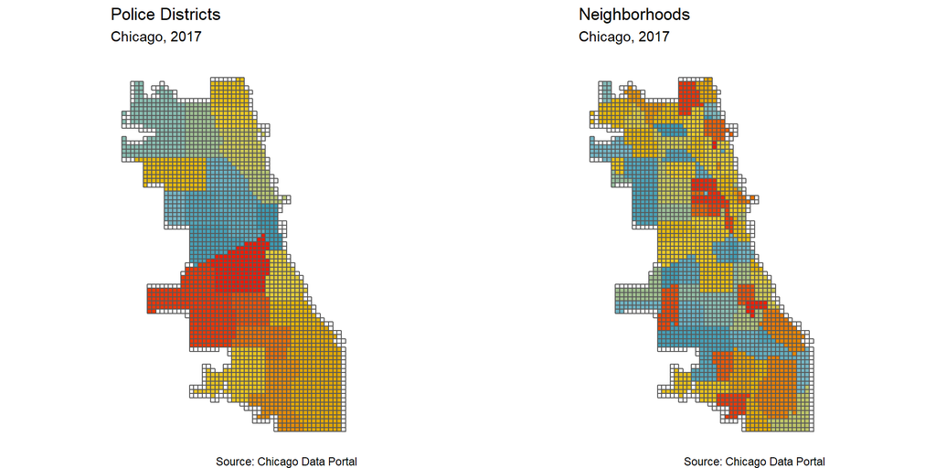

```r
final_net <-
  left_join(crime_net, st_drop_geometry(vars_net), by="uniqueID")

final_net <-
  st_centroid(final_net) %>%
    st_join(dplyr::select(neighborhoods, name), by = "uniqueID") %>%
    st_join(dplyr::select(policeDistricts, District), by = "uniqueID") %>%
      st_drop_geometry() %>%
      left_join(dplyr::select(final_net, geometry, uniqueID)) %>%
      st_sf() %>%
  na.omit()

L <- ggplot()+
  geom_sf(data=final_net, aes(fill=District), color= NA, show.legend = FALSE)+
  geom_sf(data=fishnet, fill=NA)+
  scale_fill_manual(values = col22)+
  labs(title="Police Districts",
       subtitle="Chicago, 2017\n",
       caption="Source: Chicago Data Portal")+
  theme_void()

M <- ggplot()+
  geom_sf(data=final_net, aes(fill=name), color= NA, show.legend = FALSE)+
  geom_sf(data=fishnet, fill=NA)+
  scale_fill_manual(values = col96)+
  labs(title="Neighborhoods",
       subtitle="Chicago, 2017\n",
       caption="Source: Chicago Data Portal")+
  theme_void()

ggarrange(L,M, align="v")
```

# E. Spatial Processes

### I. Local Moran’s I Statistic

The Local Moran’s I Statistic is calculated for weapons violations in Chicago. The Moran’s I statistics is near 30% towards the west of Chicago which suggests some positive spatial autocorrelation, or clustering of weapons violation crimes.The p-value suggest that weapons violations cluster more than what is expected due to random chance alone. The significant hotspot maps suggests that there is more than one occurrence of clustering of hotspots around the city.

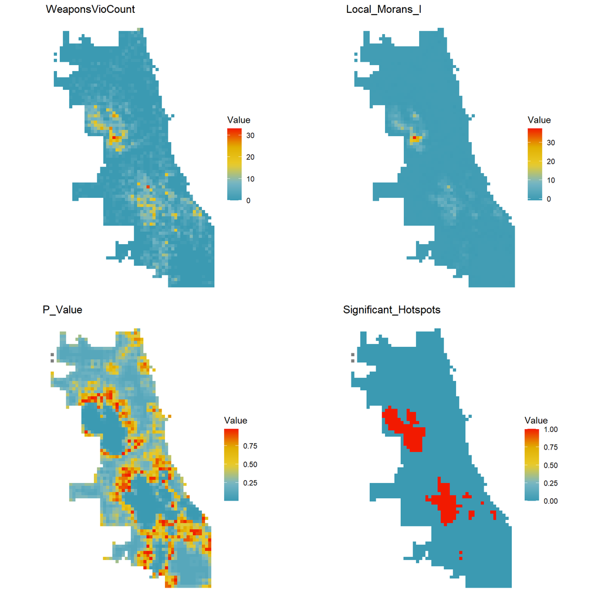

```r
final_net.nb <- poly2nb(as_Spatial(final_net), queen=TRUE)

final_net.weights <- nb2listw(final_net.nb, style="W", zero.policy=TRUE)

local_morans <- localmoran(final_net$countWeaponsVio, final_net.weights, zero.policy=TRUE) %>%
  as.data.frame()

final_net.localMorans <-
  cbind(local_morans, as.data.frame(final_net)) %>%
  st_sf() %>%
  dplyr::select(WeaponsVioCount = countWeaponsVio,
                Local_Morans_I = Ii,
                P_Value = `Pr(z != E(Ii))`) %>%
  mutate(Significant_Hotspots = ifelse(P_Value <= 0.001, 1, 0)) %>%
  gather(Variable, Value, -geometry)

vars <- unique(final_net.localMorans$Variable)
varList <- list()

for(i in vars){
  varList[[i]] <-
    ggplot() +
      geom_sf(data = filter(final_net.localMorans, Variable == i),
              aes(fill = Value), colour=NA) +
      scale_fill_gradientn(colors=pal) +
      labs(title=i) +
      theme_void()}

do.call(ggarrange,c(varList))
```

### II. Distance to Hotspots

The map shown below indicates the distance to weapons violation hotspots, by creating a dummy variable called `weaponsvio.isSig`.

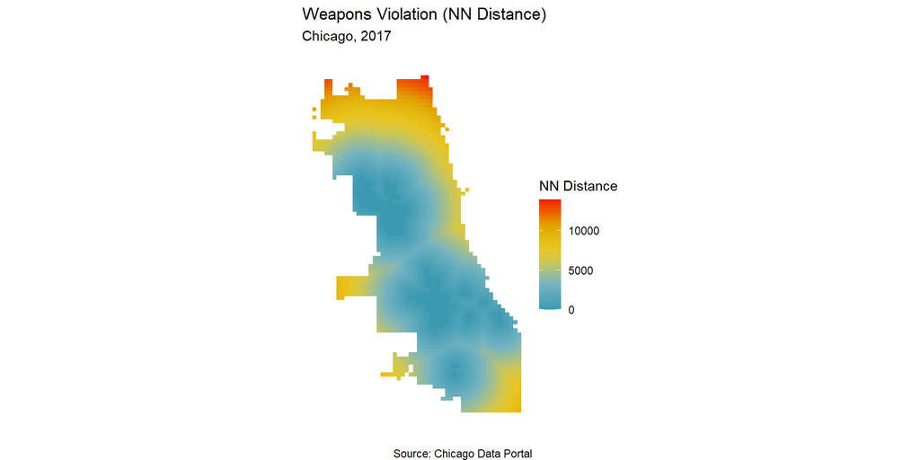

```r
final_net <- final_net %>%
  mutate(weaponsvio.isSig =
           ifelse(local_morans[,5] <= 0.001, 1, 0)) %>%
  mutate(weaponsvio.isSig.dist =
           nn_function(st_c(st_coid(final_net)),
                       st_c(st_coid(filter(final_net,
                                           weaponsvio.isSig == 1))),
                       k = 1))

ggplot() +
      geom_sf(data = final_net, aes(fill=weaponsvio.isSig.dist), colour=NA) +
      scale_fill_gradientn(colors=col10, name="NN Distance") +
  labs(title = "Weapons Violation (NN Distance)",
       subtitle="Chicago, 2017\n",
       caption="\nSource: Chicago Data Portal")+
  theme_void()
```

### III. Correlation Scatterplot

The series of graphs shown below indicate the **Number of Weapons Violations as a function of Risk Factors**. The graphs indicate a negative correlation between distance to spatial risk factors and the dependent variable- occurrences of weapons violations.

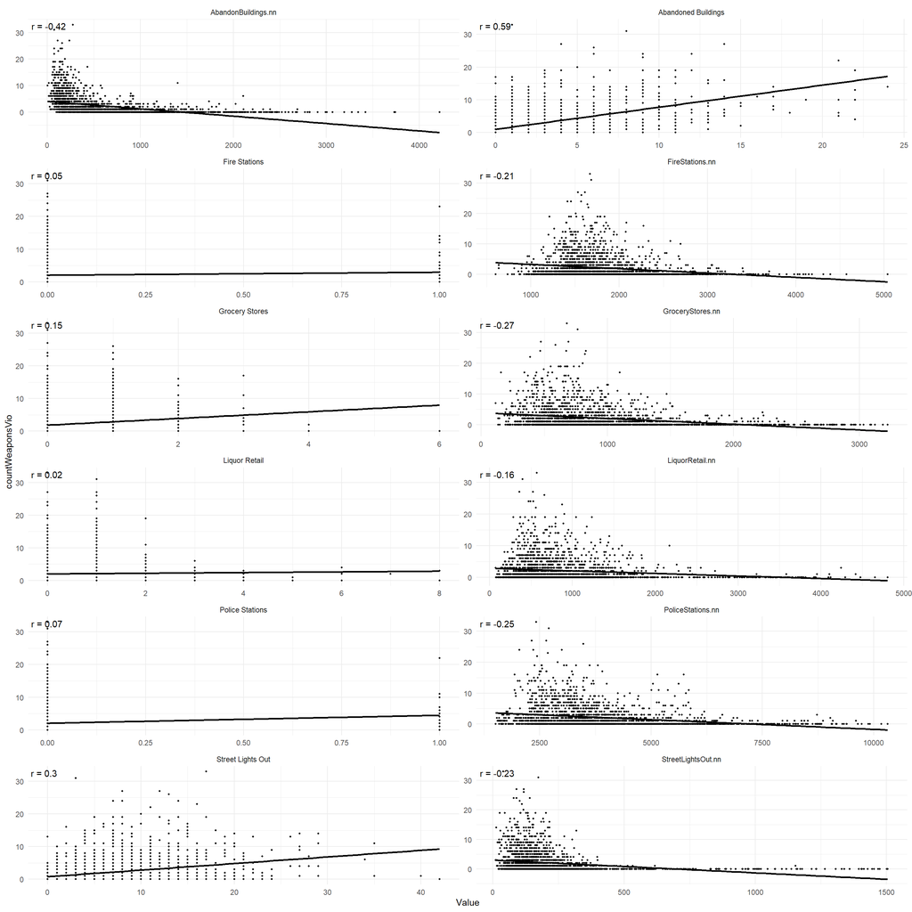

```r
correlation.long <-
  st_drop_geometry(final_net) %>%
  dplyr::select(-uniqueID, -cvID, -name, -District, -weaponsvio.isSig,
                -weaponsvio.isSig.dist) %>%
  gather(Variable, Value, -countWeaponsVio)

correlation.long$Value <- as.numeric(correlation.long$Value)

correlation.cor <-
  correlation.long %>%
  group_by(Variable) %>%
  summarize(correlation = cor(Value, countWeaponsVio))

ggplot(correlation.long, aes(Value, countWeaponsVio)) +
  geom_point(size = 0.8) +
  geom_text(data = correlation.cor, aes(label = paste("r =", round(correlation, 2))),
            x=-Inf, y=Inf, vjust = 1.5, hjust = -.1) +
  geom_smooth(method = "lm", se = FALSE, colour = "black") +
  facet_wrap(~Variable, ncol = 2, scales = "free") +
  theme_minimal()
```

### IV. Histogram of Dependent Variable

The histogram below indicates occurrences of the dependent variable- counts of weapons violations in the city.

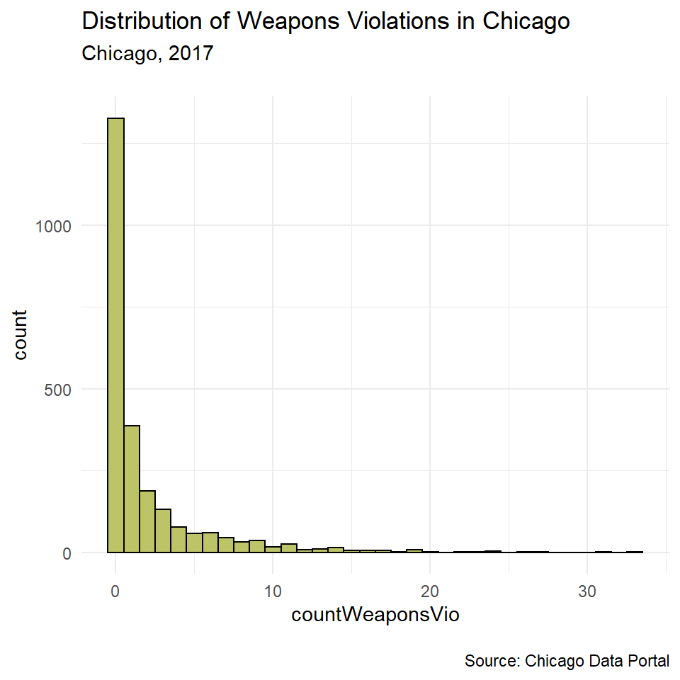

```r
ggplot(crime_net, aes(countWeaponsVio)) +
  geom_histogram(binwidth = 1, color = 'black', fill="#bdc367") +
  labs(title = "Distribution of Weapons Violations in Chicago",
       subtitle="Chicago, 2017\n",
       caption="\nSource: Chicago Data Portal")+
  theme_minimal()
```

# F. Cross Validation & Regressions

### I. Poisson Regression

In this section, the cross validated poisson regression is used to test generalizability, to see how well the model performs in other areas. To test this, two methods are used: the **k-fold technique** and the **LOGO-CV technique**.

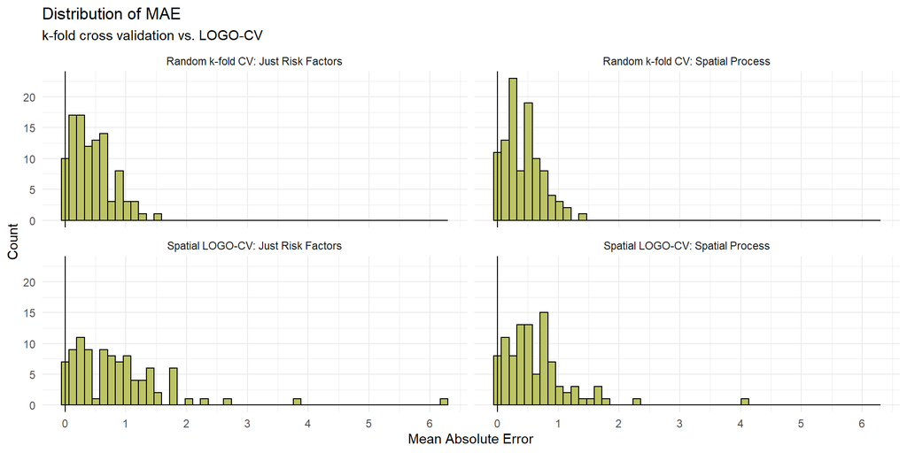

```r
reg.vars <- c("PoliceStations.nn","GroceryStores.nn","FireStations.nn",
              "LiquorRetail.nn","StreetLightsOut.nn","AbandonBuildings.nn")

reg.ss.vars <- c("PoliceStations.nn","GroceryStores.nn","FireStations.nn",
                 "LiquorRetail.nn","StreetLightsOut.nn","AbandonBuildings.nn",
                 "weaponsvio.isSig", "weaponsvio.isSig.dist")

reg.cv <- crossValidate(
  dataset = final_net,
  id = "cvID",
  dependentVariable = "countWeaponsVio",
  indVariables = reg.vars) %>%
  dplyr::select(cvID = cvID, countWeaponsVio, Prediction, geometry)

reg.ss.cv <- crossValidate(
  dataset = final_net,
  id = "cvID",
  dependentVariable = "countWeaponsVio",
  indVariables = reg.ss.vars) %>%
  dplyr::select(cvID = cvID, countWeaponsVio, Prediction, geometry)

reg.spatialCV <- crossValidate(
  dataset = final_net,
  id = "name",
  dependentVariable = "countWeaponsVio",
  indVariables = reg.vars) %>%
  dplyr::select(cvID = name, countWeaponsVio, Prediction, geometry)

reg.ss.spatialCV <- crossValidate(
  dataset = final_net,
  id = "name",
  dependentVariable = "countWeaponsVio",
  indVariables = reg.ss.vars) %>%
  dplyr::select(cvID = name, countWeaponsVio, Prediction, geometry)

reg.summary <-
  rbind(
    mutate(reg.cv, Error = Prediction - countWeaponsVio,
           Regression = "Random k-fold CV: Just Risk Factors"),
    mutate(reg.ss.cv, Error = Prediction - countWeaponsVio,
           Regression = "Random k-fold CV: Spatial Process"),
    mutate(reg.spatialCV, Error = Prediction - countWeaponsVio,
           Regression = "Spatial LOGO-CV: Just Risk Factors"),
    mutate(reg.ss.spatialCV, Error = Prediction - countWeaponsVio,
           Regression = "Spatial LOGO-CV: Spatial Process")) %>%
    st_sf()

error_by_reg_and_fold <-
  reg.summary %>%
    group_by(Regression, cvID) %>%
    summarize(Mean_Error = mean(Prediction - countWeaponsVio, na.rm = T),
              MAE = mean(abs(Mean_Error), na.rm = T),
              SD_MAE = mean(abs(Mean_Error), na.rm = T)) %>%
  ungroup()

error_by_reg_and_fold %>%
  ggplot(aes(MAE)) +
    geom_histogram(bins = 50, colour="black", fill = "#bdc367") +
    facet_wrap(~Regression) +
    geom_vline(xintercept = 0) + scale_x_continuous(breaks = seq(0, 8, by = 1)) +
    labs(title="Distribution of MAE", subtitle = "k-fold cross validation vs. LOGO-CV",
         x="Mean Absolute Error", y="Count") +
    theme_minimal()
```

```r
st_drop_geometry(error_by_reg_and_fold) %>%
  group_by(Regression) %>%
    summarize(Mean_MAE = round(mean(MAE), 2),
              SD_MAE = round(sd(MAE), 2)) %>%
  kable() %>%
    kable_styling(full_width = F)
```

| Regression | Mean_MAE | SD_MAE |
| --- | --- | --- |
| Random k-fold CV: Just Risk Factors | 0.45 | 0.33 |
| Random k-fold CV: Spatial Process | 0.42 | 0.30 |
| Spatial LOGO-CV: Just Risk Factors | 0.87 | 0.86 |
| Spatial LOGO-CV: Spatial Process | 0.64 | 0.58 |

### II. Regression Errors for Predicting Weapons Violations

The maps below model the mean absolute error for Random K-Fold and Spatial Cross Validation.

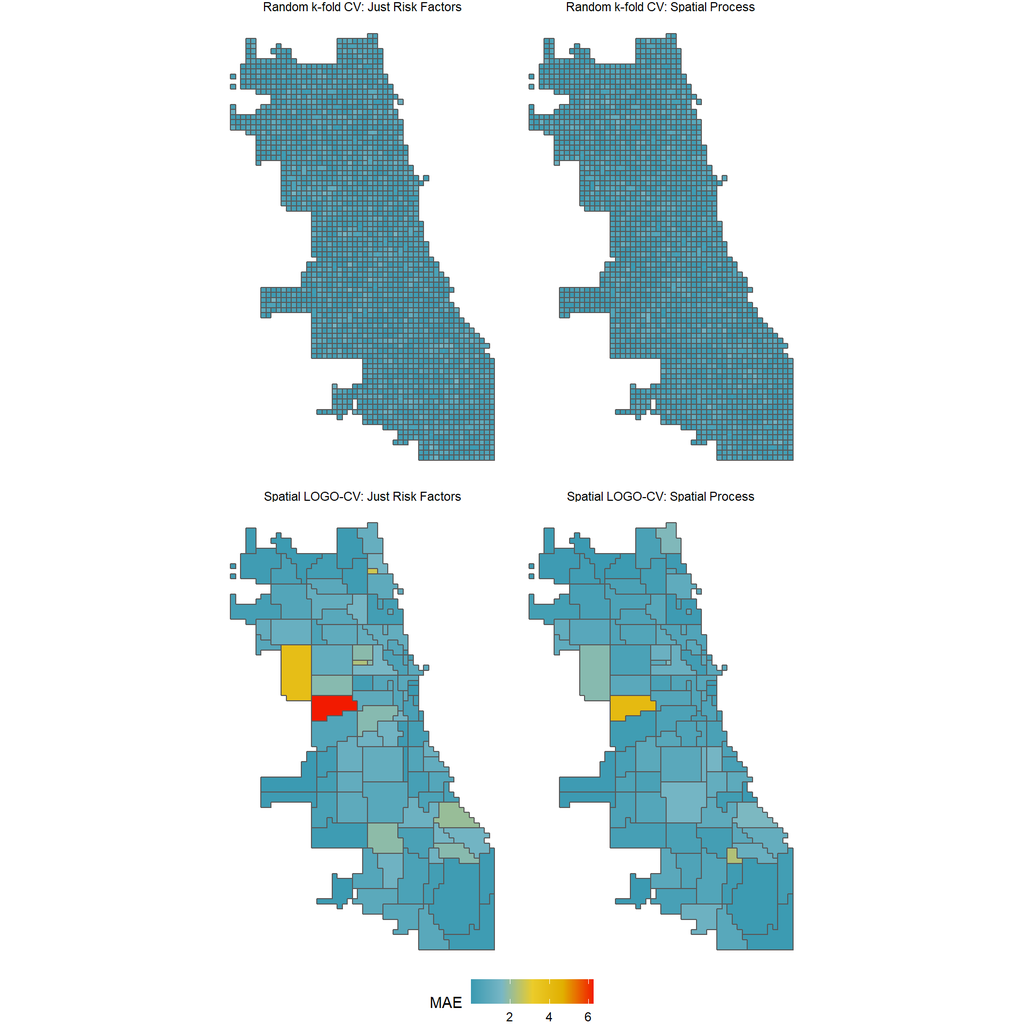

```r
error_by_reg_and_fold %>%
  ggplot() +
    geom_sf(aes(fill = MAE)) +
    facet_wrap(~Regression) +
    scale_fill_gradientn(colors=col29) +
    theme_void() + theme(legend.position="bottom")
```

### III. Generalizability by Neighborhood Context

This section uses demographic data for Chicago for the year 2018, to understand how well the model predicts weapons violations for areas that are majority white and majority non-white.

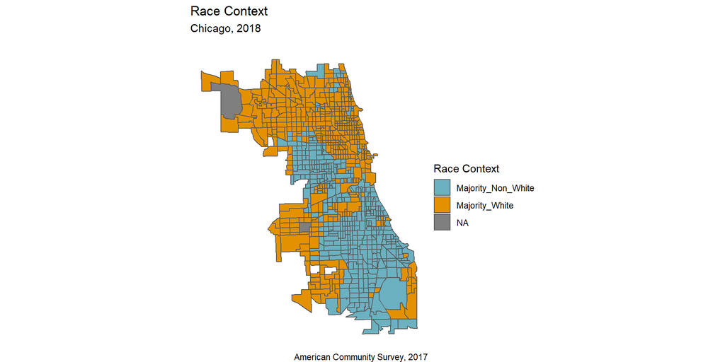

```r
tracts18 <-
  get_acs(geography = "tract", variables = c("B01001_001E","B01001A_001E"),
          year = 2018, state=17, county=031, geometry=T) %>%
  st_transform('ESRI:102271')  %>%
  dplyr::select(variable, estimate, GEOID) %>%
  spread(variable, estimate) %>%
  rename(TotalPop = B01001_001,
         NumberWhites = B01001A_001) %>%
  mutate(percentWhite = NumberWhites / TotalPop,
         raceContext = ifelse(percentWhite > .5, "Majority_White", "Majority_Non_White")) %>%
  .[neighborhoods,]

ggplot()+
  geom_sf(data=tracts18, aes(fill=raceContext)) +
  scale_fill_manual(values=c("#6bb1c1","#e49100"), name= "Race Context")+
  labs(title="Race Context",
       subtitle="Chicago, 2018\n",
       caption="American Community Survey, 2017")+
  theme_void()
```

The model which uses the k-fold CV method and incorporates spatial processes predicts weapons violations better in majority non-white areas.

```r
reg.summary %>%
  st_centroid() %>%
  st_join(tracts18) %>%
  na.omit() %>%
  st_drop_geometry() %>%
  group_by(Regression, raceContext) %>%
  summarize(mean.Error = mean(Error, na.rm = T)) %>%
  spread(raceContext, mean.Error) %>%
  kable(caption = "Mean Error by Neighborhood Racial Context") %>%
  kable_styling(full_width = F)
```

Mean Error by Neighborhood Racial Context

| Regression | Majority_Non_White | Majority_White |
| --- | --- | --- |
| Random k-fold CV: Just Risk Factors | -0.3107351 | 0.3412144 |
| Random k-fold CV: Spatial Process | -0.1466162 | 0.1600419 |
| Spatial LOGO-CV: Just Risk Factors | -0.3558191 | 0.3532894 |
| Spatial LOGO-CV: Spatial Process | -0.1621744 | 0.1670487 |

# G. Kernel Density vs. Predictions

### I. Kernel Width

To compare out model with a kernel density model that flattens out incidences, kernel density maps are plotted at 3 different search radii. It can be observed that in each case, there seems to be two primary hotspots for weapons violations.

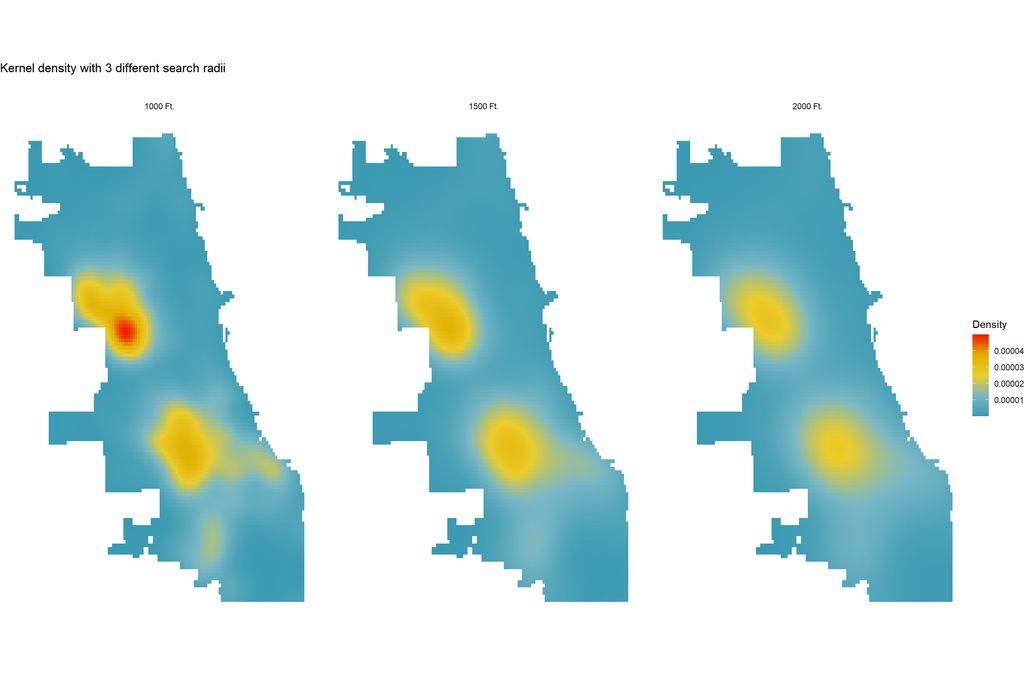

```r
wepvio_ppp <- as.ppp(st_coordinates(weaponsvio), W = st_bbox(final_net))
wepvio_KD.1000 <- spatstat.core::density.ppp(wepvio_ppp, 1000)
wepvio_KD.1500 <- spatstat.core::density.ppp(wepvio_ppp, 1500)
wepvio_KD.2000 <- spatstat.core::density.ppp(wepvio_ppp, 2000)
wepvio_KD.df <- rbind(
  mutate(data.frame(rasterToPoints(mask(raster(wepvio_KD.1000), as(neighborhoods, 'Spatial')))), Legend = "1000 Ft."),
  mutate(data.frame(rasterToPoints(mask(raster(wepvio_KD.1500), as(neighborhoods, 'Spatial')))), Legend = "1500 Ft."),
  mutate(data.frame(rasterToPoints(mask(raster(wepvio_KD.2000), as(neighborhoods, 'Spatial')))), Legend = "2000 Ft."))


wepvio_KD.df$Legend <- factor(wepvio_KD.df$Legend, levels = c("1000 Ft.", "1500 Ft.", "2000 Ft."))

ggplot(data=wepvio_KD.df, aes(x=x, y=y)) +
  geom_raster(aes(fill=layer)) +
  facet_wrap(~Legend) +
  coord_sf(crs=st_crs(final_net)) +
  scale_fill_gradientn(colors=col29, name="Density") +
  labs(title = "Kernel density with 3 different search radii\n\n") +
  theme_void()
```

### III. Weapons Violations, 2017

The map below overlays the kernel density model with fishnet cells to show clustering of crime hotspots.

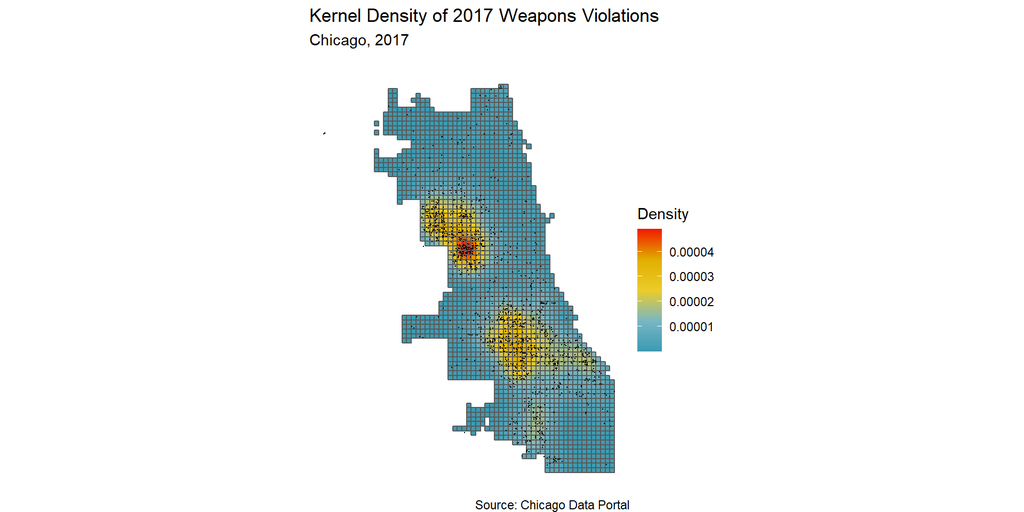

```r
as.data.frame(wepvio_KD.1000) %>%
  st_as_sf(coords = c("x", "y"), crs = st_crs(final_net)) %>%
  aggregate(., final_net, mean) %>%
   ggplot() +
     geom_sf(aes(fill=value)) +
     geom_sf(data = sample_n(weaponsvio, 1500), size = .1) +
     scale_fill_gradientn(colors=col29, name="Density") +
     labs(title = "Kernel Density of 2017 Weapons Violations",
          subtitle="Chicago, 2017\n",
       caption="Source: Chicago Data Portal")+
  theme_void()
```

# G. Comparisons

### I. Comparing of Kernel Density and Risk Predictions

The maps below compare the kernel density model to the risk prediction model. It can be observed that there are some overlaps in primary hotspots between both models, but the kernel density model seems to have over simplified the occurances of weapons violations, while the risk prediction model shows variation in its distribution.

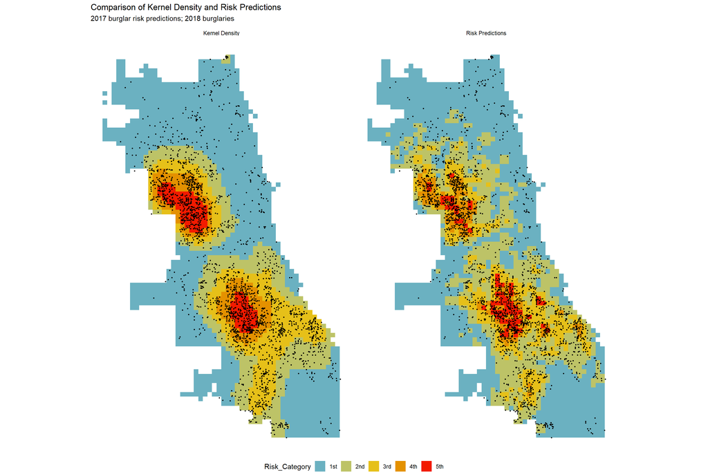

```r
weaponsvio18 <-
  read.socrata("https://data.cityofchicago.org/Public-Safety/Crimes-2018/3i3m-jwuy") %>%
  filter(Primary.Type == "WEAPONS VIOLATION")%>%
  mutate(x = gsub("[()]", "", Location)) %>%
  separate(x,into= c("Y","X"), sep=",") %>%
  mutate(X = as.numeric(X),
         Y = as.numeric(Y)) %>%
  na.omit %>%
  st_as_sf(coords = c("X", "Y"), crs = 4326, agr = "constant") %>%
  st_transform('ESRI:102271') %>%
  distinct() %>%
  .[fishnet,]

wepvio_KDE_sum <- as.data.frame(wepvio_KD.1000) %>%
  st_as_sf(coords = c("x", "y"), crs = st_crs(final_net)) %>%
  aggregate(., final_net, mean)
kde_breaks <- classIntervals(wepvio_KDE_sum$value,
                             n = 5, "fisher")
wepvio_KDE_sf <- wepvio_KDE_sum %>%
  mutate(label = "Kernel Density",
         Risk_Category = classInt::findCols(kde_breaks),
         Risk_Category = case_when(
           Risk_Category == 5 ~ "5th",
           Risk_Category == 4 ~ "4th",
           Risk_Category == 3 ~ "3rd",
           Risk_Category == 2 ~ "2nd",
           Risk_Category == 1 ~ "1st")) %>%
  cbind(
    aggregate(
      dplyr::select(weaponsvio18) %>% mutate(wepvioCount = 1), ., sum) %>%
    mutate(wepvioCount = replace_na(wepvioCount, 0))) %>%
  dplyr::select(label, Risk_Category, wepvioCount)

ml_breaks <- classIntervals(reg.ss.spatialCV$Prediction,
                             n = 5, "fisher")
wepvio_risk_sf <-
  reg.ss.spatialCV %>%
  mutate(label = "Risk Predictions",
         Risk_Category =classInt::findCols(ml_breaks),
         Risk_Category = case_when(
           Risk_Category == 5 ~ "5th",
           Risk_Category == 4 ~ "4th",
           Risk_Category == 3 ~ "3rd",
           Risk_Category == 2 ~ "2nd",
           Risk_Category == 1 ~ "1st")) %>%
  cbind(
    aggregate(
      dplyr::select(weaponsvio18) %>% mutate(wepvioCount = 1), ., sum) %>%
      mutate(wepvioCount = replace_na(wepvioCount, 0))) %>%
  dplyr::select(label,Risk_Category, wepvioCount)

rbind(wepvio_KDE_sf, wepvio_risk_sf) %>%
  na.omit() %>%
  gather(Variable, Value, -label, -Risk_Category, -geometry) %>%
  ggplot() +
    geom_sf(aes(fill = Risk_Category), colour = NA) +
    geom_sf(data = sample_n(weaponsvio18, 3000), size = .5, colour = "black") +
    facet_wrap(~label, ) +
    scale_fill_manual(values = c("#6bb1c1","#bdc367","#e6c019","#e49100","#f21a00")) +
    labs(title="Comparison of Kernel Density and Risk Predictions",
         subtitle="2017 burglar risk predictions; 2018 burglaries\n") +
    theme_void() + theme(legend.position="bottom")
```

### II. Bar Plot

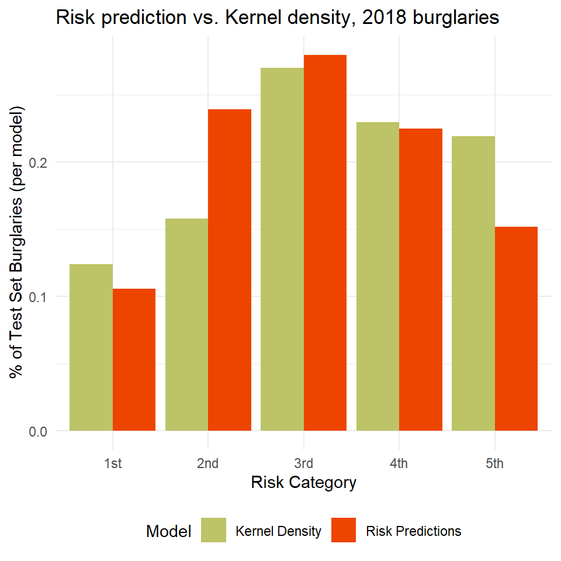

```r
rbind(wepvio_KDE_sf, wepvio_risk_sf) %>%
  st_drop_geometry() %>%
  na.omit() %>%
  gather(Variable, Value, -label, -Risk_Category) %>%
  group_by(label, Risk_Category) %>%
  summarize(countWepVio = sum(Value)) %>%
  ungroup() %>%
  group_by(label) %>%
  mutate(Pcnt_of_test_set_crimes = countWepVio / sum(countWepVio)) %>%
    ggplot(aes(Risk_Category,Pcnt_of_test_set_crimes)) +
      geom_bar(aes(fill=label), position="dodge", stat="identity") +
      scale_fill_manual(values =c("#bdc367","#ed4400") , name = "Model") +
      labs(title = "Risk prediction vs. Kernel density, 2018 burglaries",
           y = "% of Test Set Burglaries (per model)",
           x = "Risk Category") +
  theme_minimal()+ theme(legend.position="bottom")
```

# H. Conclusion

The model created at the end of this study had a mean absolute error (MAE) of 0.42 and generalizes well across different neighborhoods. This model considered spatial risk factors like proximity to police stations, grocery stores, liquor retail stores etc. and used the k-fold cross validation method. However, it cannot be said that the model is free of bias as it seems to predict better in areas that are majority non-white, compared to areas that are majority white tracts.

When compared to the kernel density model, which seems to overlook the granular variations in occurrences of weapons violations, our model does seem to take this variations into consideration. Overall, the model from this study does show some advantages over the traditional kernel density model and can be used as a base for future predictive policing research- provided more spatial risk factors are incorporated into model. It would also be interesting to look at how occurrences of weapons violations are related to political biases- say, how do these occurrences vary in areas that are majority republican voters versus democrats.